# Algorithm Class - Practice 13 - Map / Set / Hash

2018/7/27

# Set

A collection that **cannot contain duplicate elements**.

The Java platform contains three general-purpose Set implementations: **HashSet**, TreeSet, and LinkedHashSet.

- **HashSet**: which stores its elements in a **hashtable**, is the best-performing implementation; however it makes no guarantees concerning the order of iteration
- **TreeSet**: which stores its elements in a red-black tree (balanced binary search tree), **orders** its elements based on their values
- **LinkedHashSet**: it is a HashSet and also it is a LinkedList, it maintains the order when each of the elements is inserted into the HashSet.

# Map

A collection that maps keys to values. A Map cannot contain duplicate keys; each key can map to one value.

- A collection that stores <key, value> pairs, such that no duplicate keys are allowed.

The Java platform contains three general-purpose Map implementations: **HashMap**, TreeMap, and LinkedHashMap.

# Hash Map

## Common API

[link](https://docs.oracle.com/javase/8/docs/api/java/util/HashMap.html)

- `put(K key, V value)`
- `get(Object key)`
- `remove(K key)`
- `boolean containsKey(Object key)`
- Set<Map.Entry<K, V>> entrySet() - get the set **view** of all the entries in the hashmap
- Set<K> keySet() - get the set **view** of all the keys in the haspmap
- Collection<V> values() - get the collection **view** of all the values in the hashmap
- `boolean containValue(V value)` - O(n)
- `void clear()`
- `int size()`
- `boolean isEmpty()`

```java
public class HashUsing {
  public HashUsing() {}

  public static void main(String[] args) {
    Map<String, Integer> employerNumbers = new HashMap<>();
    employerNumbers.put("yahoo", 1);
    System.out.println(employerNumbers);  //{yahoo : 1}

    employerNumbers.put("google", 2);
    System.out.println(employerNumbers);  //{yahoo : 1, google : 2}
    Integer yc = employerNumbers.get("yahoo");  //yc = 1

    //yc is the previous value for key "yahoo"
    yc = employerNumbers.put("yahoo", 5);  //{yahoo : 5, google : 2}
    System.out.println(yc);  //yc = 1

    yc = employerNumbers.get("yahoo");  //yc = 5
    //fc = null (if the key is not in the map, get(key) will return null)
    Integer fc = employerNumbers.get("facebook");

    //fe = false;
    boolean fe = employerNumbers.containsKey("facebook");

    fc = employerNumbers.remove("facebook");
    System.out.println(fc);  //fc = null

    //{yahoo : 5, google : 2}
    Integer gc = employerNumbers.remove("google");

    System.out.println(gc);  //2
    System.out.println(employerNumbers);  {yahoo : 5}
  }
}
```

## Time Complexity

| Operation | Average | Worst |
| --- | --- | --- |
| search: boolean containsKey(Object key); get(K key) | O(1) | O(n) |
| insert/update: put(K key, V value) | O(1) | O(n) |
| delete: remove(K key) | O(1) | O(n) |

## HashMap vs. Hashtable

Similar to ArrayList vs. Vector

Vector, Hashtable exist from Java 1.0

ArrayList, HashMap introduced from Java 5

1. Hashtable does not allow null key, but HashMap allows one null key.
2. Vector and Hashtable operations are synchronized, introduce a lot of performance penalty

**We do not use Hashtable anymore.**

## A HashMap implementation - 1

- A table of **buskets** (an array of buckets), using the array index to denote each bucket.
- For each <key, value>, it goes to one of the buckets, the bucket index is determined by a **hash function** applied on **key** and the size of array.

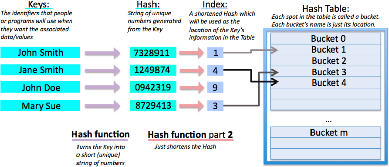

- **Collision Control**
  - Collision - two keys mapped to the same bucket.
  - **Separate Chaining** (Close Addressing) - the element of each of tje buckets is actually a single linked list.
  - Open addressing - put the key-value pair into the “next” available bucket.
    - How to define next? Linear / quadratic / exponential probing, hash again
    - Challenge: handling removed keys in the map
    - Not used by Java, but by some real life systems.
  - If different Keys are determined to use the same bucket, they will be chained in the list.

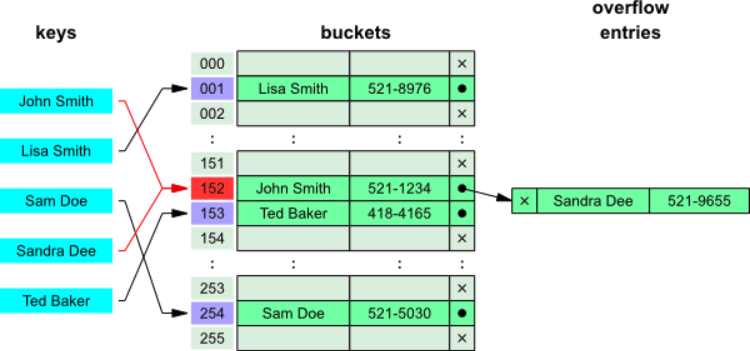

- What are the elements in the buckets? Singly Linked List, each node contains one <key, value> pair

```java
class Entry<K, V> {
  K key;
  V value;
  Entry<K, V> next;
}
```

**HashMap operations**

- `put(key, value)`
  1. `int hash = hash(key)` - hash
  2. `int index = hash % table_size` - index
  3. search for the list resides in the buckets to see if the key already exists
     1. if not find the same key already existed, add a new Entry node to the list
     2. if find an Entry with the same key, update the value of that Entry
- `get(key)`
  1. `int hash = hash(key)` - hash
  2. `int index = hash % table_size` - index
  3. search for the list resides in the buckets to see if the key already exists

*HashMap can only has one null key, it is always mapped to bucket 0.*

**Get into a little details about HashMap Implementation:**

- array of entries
- each entry is actually a singly linked list (handle collision)
  - contains the <key, value> pair
1. Define the class for each entry:
2. maintain an array of entries
- Entry<K, V>[] array;
  - To get(K key), put()
3. hash(key) to get the hash#
4. from the hash#, mapped to the entry index.
5. When iterate the corresponding entry for the given key, which is actually a singly linked list, we need compare each of the entry in the list, if **the key is the same** as the key we want.

**Two Questions Here:**

1. “HashMap get(key), put(key, value), remove(key) is O(1)”, is it always true? What is the major factor affecting the time complexity? **hash(key) -> key.hashCode()**
2. When we need to know if a key is already in the HashMap, we need to find its bucket, then traverse the linked list in that bucket to see if there is a same key already existed. How do we defind “the same key”? **key.equals(anotherKey)**

# ==, equal(), hashCode()

- ==
  - determine if two primitive types have the same value.
  - **determide if two references are pointed to the same objects.**
- equals(), hashCode()
  - definded in **Object** class, Object is the root class for any Java class.
  - any Java class **implicitly extends** Object class, so if in the subclass these two methods are not overridden, it inherits what it defines in Object class.
  - the default implementation of equals() is check if the two references are pointed to the same object “==”.
  - the default implementation of hashCode() return a “unique hash value” for the object based on its memory address.
- 接上
  - sometimes we do not want to compare the reference… we want to compare the object’s content.

**`hashCode()` is VERY important!**

1. The performance of HashMap solely depends on how good the `hashCode()` is.
   - bad `hashCode()` can lead to linear time complexity in extreme case, for example, if all the keys has thesame hash number returned by `.hashCode()`.
2. easy, fast, efficient
3. minimize collision, as evenly distributed as possible

## Common hashCode() implementation

```java
class Combo {
  int a;
  B b;
  C c;

  public Combo(int a, B b, C c) {
    this.a = a;
    this.b = b;
    this.c = c;
  }

  @Override
  public int hashCode() {
    return a * 31 + b.hashCode() * 31 + c.hashCode();  //or 101
  }
}
```

## Rehashing, load factor

- Rehashing
  - is needed when there are too many <key, value> pairs maintained in the hashmap -> too many collision.
  - expand the array to a larger one and move all the <key, value> pairs to the new array (in HashMap by default, the array size is **doubled** each time).
  - **Rehashing is global wise - meaning all the <key, value> pairs need to participate.**
- load factor
  - to control when rehashing is needed, maintain the ratio of **number of <key, value> pairs / number of buckets**
  - default 0.75
  - when the ratio exceedsthe limit, rehashing will happen

# HashSet

It is backed up by a HashMap instance. Only care about the Key here.

## Common API

- link
- boolean add(E e)
- boolean remove(Object o)
- boolean contains(Oject o)
- void clear()
- int size()
- boolean isEmpty()

```java
class HashSet<K> {

}
```